# Texas Real Estate

Luca Bassem Abdul Hay

2023-11-29

## Real Estate market in Texas

This is an exploratory analysis of the real estate market in Texas. The dataset contains real estate meausures for the main Texas cities from 2010 to 2014. The variables contained in the dataset are the following:  
- city  
- year  
- month  
- sales, the total number of sales in that period  
- volume, total value of sales in M$  
- median_price: the median selling price in $  
- listings: number of active listings  
- months_inventory: expected time in months to sell all the assets listed at the current selling pace

Here is the dataset:

```
##      city                year          month           sales
##  Length:240         Min.   :2010   Min.   : 1.00   Min.   : 79.0
##  Class :character   1st Qu.:2011   1st Qu.: 3.75   1st Qu.:127.0
##  Mode  :character   Median :2012   Median : 6.50   Median :175.5
##                     Mean   :2012   Mean   : 6.50   Mean   :192.3
##                     3rd Qu.:2013   3rd Qu.: 9.25   3rd Qu.:247.0
##                     Max.   :2014   Max.   :12.00   Max.   :423.0
##      volume        median_price       listings    months_inventory
##  Min.   : 8.166   Min.   : 73800   Min.   : 743   Min.   : 3.400
##  1st Qu.:17.660   1st Qu.:117300   1st Qu.:1026   1st Qu.: 7.800
##  Median :27.062   Median :134500   Median :1618   Median : 8.950
##  Mean   :31.005   Mean   :132665   Mean   :1738   Mean   : 9.193
##  3rd Qu.:40.893   3rd Qu.:150050   3rd Qu.:2056   3rd Qu.:10.950
##  Max.   :83.547   Max.   :180000   Max.   :3296   Max.   :14.900
##       date
##  Min.   :2010-01-01
##  1st Qu.:2011-03-24
##  Median :2012-06-16
##  Mean   :2012-06-16
##  3rd Qu.:2013-09-08
##  Max.   :2014-12-01
```

The variable types are the following:

```
##             city             year            month            sales
##      "character"        "integer"        "integer"        "integer"
##           volume     median_price         listings months_inventory
##        "numeric"        "numeric"        "integer"        "numeric"
##             date
##           "Date"
```

### Position indexes

The distribution of frequency for relevant variables:

| City | Absolute Frequency | Relative Frequency |
| --- | --- | --- |
| Beaumont | 60 | 0.25 |
| Bryan-College Station | 60 | 0.25 |
| Tyler | 60 | 0.25 |
| Wichita Falls | 60 | 0.25 |

| Year | Absolute Frequency | Relative Frequency |
| --- | --- | --- |
| 2010 | 48 | 0.2 |
| 2011 | 48 | 0.2 |
| 2012 | 48 | 0.2 |
| 2013 | 48 | 0.2 |
| 2014 | 48 | 0.2 |

| Month | Absolute Frequency | Relative Frequency |
| --- | --- | --- |
| 1 | 20 | 0.08 |
| 2 | 20 | 0.08 |
| 3 | 20 | 0.08 |
| 4 | 20 | 0.08 |
| 5 | 20 | 0.08 |
| 6 | 20 | 0.08 |
| 7 | 20 | 0.08 |
| 8 | 20 | 0.08 |
| 9 | 20 | 0.08 |
| 10 | 20 | 0.08 |
| 11 | 20 | 0.08 |
| 12 | 20 | 0.08 |

### Position indexes & Variability indexes

As per the main **position indexes** I used the function “sumtable” from *vtable* package for ease of use. In fact, this function is a very flexible tool that returns the summary indexes of my interest. I then compute the main variability indexes for each variable (range, IQR, variance, sd, CV) and the shape indexes (skewness, kurtosis) for the same variables.

Position indexes for Texas dataset

| Variable | N | Mean | Std. Dev. | Min | Q1 | Median | Q3 | Max |
| --- | --- | --- | --- | --- | --- | --- | --- | --- |
| sales | 240 | 192 | 80 | 79 | 127 | 176 | 247 | 423 |
| volume | 240 | 31 | 17 | 8.2 | 18 | 27 | 41 | 84 |
| median_price | 240 | 132665 | 22662 | 73800 | 117300 | 134500 | 150050 | 180000 |
| listings | 240 | 1738 | 753 | 743 | 1026 | 1618 | 2056 | 3296 |
| months_inventory | 240 | 9.2 | 2.3 | 3.4 | 7.8 | 8.9 | 11 | 15 |

The **variability indexes** for the relevant variables:

| Variable | Range | IQR | Variance | Std.Dev. | Coeff.Var. |
| --- | --- | --- | --- | --- | --- |
| volume | 75.38 | 23.23 | 277 | 16.65 | 53.71 |
| listings | 2553 | 1,029.50 | 566,569 | 752.71 | 43.31 |
| sales | 344 | 120.00 | 6,344 | 79.65 | 41.42 |
| months_inventory | 11.5 | 3.15 | 5 | 2.30 | 25.06 |
| median_price | 106200 | 32,750.00 | 513,572,983 | 22,662.15 | 17.08 |

The **most volatile** variable (aka the one with the highest Coefficient of Variation, which as we know is a measure of volatility that makes the variability among different variables comparable) and the **most asymmetric** one are the following:

| Variable | Coefficient of Variation |
| --- | --- |
| volume | 53.71 |
| listings | 43.31 |
| sales | 41.42 |
| months_inventory | 25.06 |
| median_price | 17.08 |

| Variable | Skewness(in Abs) |
| --- | --- |
| volume | 0.88 |
| sales | 0.72 |
| listings | 0.65 |
| median_price | 0.36 |
| months_inventory | 0.04 |

The **Kurtosis index** for the different quantitative variables is the following:

| Variable | Kurtosis |
| --- | --- |
| volume | 3.18 |
| sales | 2.69 |
| listings | 2.21 |
| median_price | 2.38 |
| months_inventory | 2.83 |

### Class distribution

I decide to divide the variable *listings* in classes. I opted for this variable because it is the second most volatile variable but only the third most skewed:

|  | ni | fi | Ni | Fi |
| --- | --- | --- | --- | --- |
| (0,1000] | 54 | 0.22 | 54 | 0.22 |
| (1000,2000] | 126 | 0.52 | 180 | 0.74 |
| (2000,3000] | 41 | 0.17 | 221 | 0.91 |
| (3000,3296] | 19 | 0.08 | 240 | 0.99 |

Here is the **barplot** of the different classes:

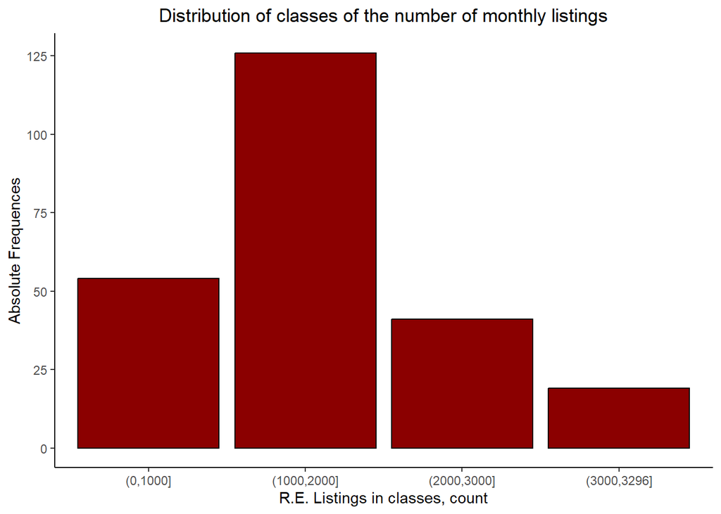

Let’s now compute the Gini index of these classes:  
**Gini index** of the listings divided in classes: 0.85

The Gini index for the variable *city* will be 1 as all the four cities are equally represented in the dataset:  
**Gini index** of the variable city: 1

### Probability

*What is the probability of picking the city “Beaumont” if we randomly pick one row of the dataset?*  
There are 60 observations that report “Beaumont” as a city over a total number of observation of 240. This means that the probability of extracting a row for which the variable *city* is “Beaument” is $\frac{60}{240} = 0.25$  
In this example, I sampled the city 1000 times and here is the result:

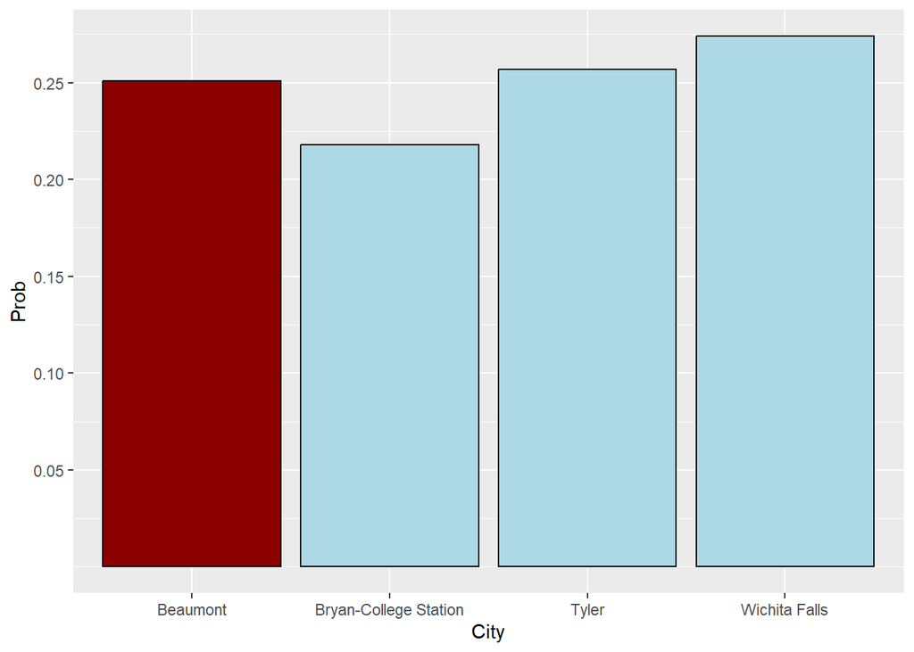

*What is the probability of picking the month “July” if we randomly pick one row of the dataset?*  
There are 5 complete years (so 5 times “July” as a month) in the dataset for all of the 4 cities in the dataset. This means that the probability of extracting a row for which the variable *city* is “Beaument” is $\frac{5*4}{240} = \frac{20}{240} = 0.08$  
In this example, I sampled the month 1000 times and here is the result:

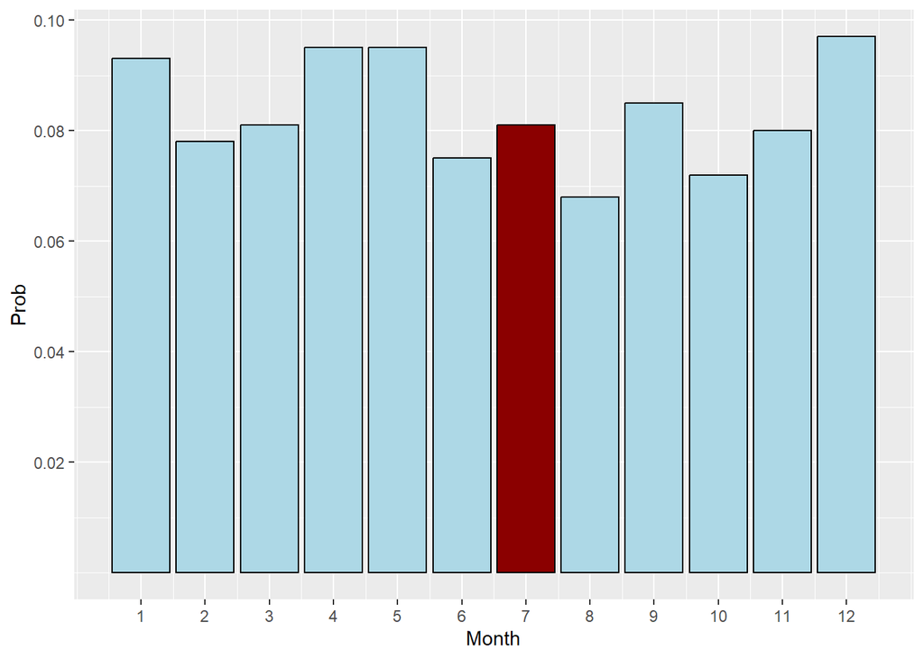

*What is the probability of picking the month of December of the year 2012 if we randomly pick one row of the dataset?*  
There are 4 observation in the dataset whose month-year key is December 2012 (one for each city). Thus $\frac{4}{240} = 0.01\overline{6}$.  
I firstly create a key month-year and then I sample the data as before. For ease of readiness, I will not show the histogram but I will rather show the computation:

```r
texas$month_year <- paste0(month,"-",year)
draw_month_year <- sample(texas$month_year, 100000, replace = T)
prob_dec_2012 <- sum(ifelse(draw_month_year == "12-2012", 1, 0))/100000
cat("<br> The probability of drawing a row from December 2012 is " , round(prob_dec_2012, 2))
```

The probability of drawing a row from December 2012 is 0.02

### Mean price

We have the information for the number of sales in each month (the variable *sales*) and the total value generated by those sales (the variable *volume*). The average price will thus be:

$Average Price = \frac{Volume}{Sales}$  
Also, a way to measure the *efficacy* of the listings would be to divide the number of sales in each row (identified by the key city-month-year) by the number of listings in that specific row. Like this:

$Listing Efficacy = \frac{Sales}{Listings}$  
This new variable would measure the rate of efficacy of the listings in each month-year in each city (i.e. out of *xxx* listings how many properties were effectively sold?)

```
##   mean_price list_efficacy
## 1   170626.5          0.05
## 2   163796.3          0.07
## 3   157697.8          0.11
## 4   134095.0          0.12
## 5   142737.6          0.11
```

### Conditional mean and Std Dev

Here I create new tables that show the mean of some variables by city, month and year:

| City | Average # of monthly listings | Average tot value of sales | Average # of monthly sales | Std.Dev. Listings | Std.Dev. Value | Std.Dev. Sales |
| --- | --- | --- | --- | --- | --- | --- |
| Beaumont | 1,679.32 | 26.13 | 177 | 91.13 | 6.97 | 41.48 |
| Bryan-College Station | 1,458.13 | 38.19 | 206 | 252.53 | 17.25 | 84.98 |
| Tyler | 2,905.05 | 45.77 | 270 | 226.75 | 13.11 | 61.96 |
| Wichita Falls | 909.58 | 13.93 | 116 | 73.76 | 3.24 | 22.15 |

| Year | Average # of listings | Average tot value of sales | Average # of sales | Std.Dev. Listings | Std.Dev. Value | Std.Dev. Sales |
| --- | --- | --- | --- | --- | --- | --- |
| 2010 | 1826.00 | 25.68 | 169 | 785.02 | 10.80 | 60.54 |
| 2011 | 1849.65 | 25.16 | 164 | 780.38 | 12.20 | 63.87 |
| 2012 | 1776.81 | 29.27 | 186 | 738.45 | 14.52 | 70.91 |
| 2013 | 1677.60 | 35.15 | 212 | 743.52 | 17.93 | 84.00 |
| 2014 | 1560.04 | 39.77 | 231 | 706.71 | 21.19 | 95.51 |

| City | Average # of listings | Average tot value of sales | Average # of sales | Std.Dev. Listings | Std.Dev. Value | Std.Dev. Sales |
| --- | --- | --- | --- | --- | --- | --- |
| 1 | 1,647.05 | 19.00 | 127 | 704.61 | 8.37 | 43.38 |
| 2 | 1,692.50 | 21.65 | 141 | 711.20 | 10.09 | 51.07 |
| 3 | 1,756.70 | 29.38 | 189 | 727.35 | 12.02 | 59.18 |
| 4 | 1,825.70 | 33.30 | 212 | 770.43 | 14.52 | 65.40 |
| 5 | 1,823.85 | 39.70 | 239 | 790.22 | 19.02 | 83.12 |
| 6 | 1,833.25 | 41.30 | 244 | 811.63 | 21.08 | 95.00 |
| 7 | 1,821.20 | 39.12 | 236 | 826.72 | 21.41 | 96.27 |
| 8 | 1,786.30 | 38.01 | 231 | 815.87 | 18.05 | 79.23 |
| 9 | 1,748.90 | 29.60 | 182 | 802.66 | 15.22 | 72.52 |
| 10 | 1,710.35 | 29.08 | 180 | 779.16 | 15.13 | 74.95 |
| 11 | 1,652.70 | 24.81 | 157 | 741.25 | 11.15 | 55.47 |
| 12 | 1,557.75 | 27.09 | 169 | 692.57 | 12.57 | 60.75 |

### Some interesting plots

I will analyse the distribution of the median price across cities using a boxplot:

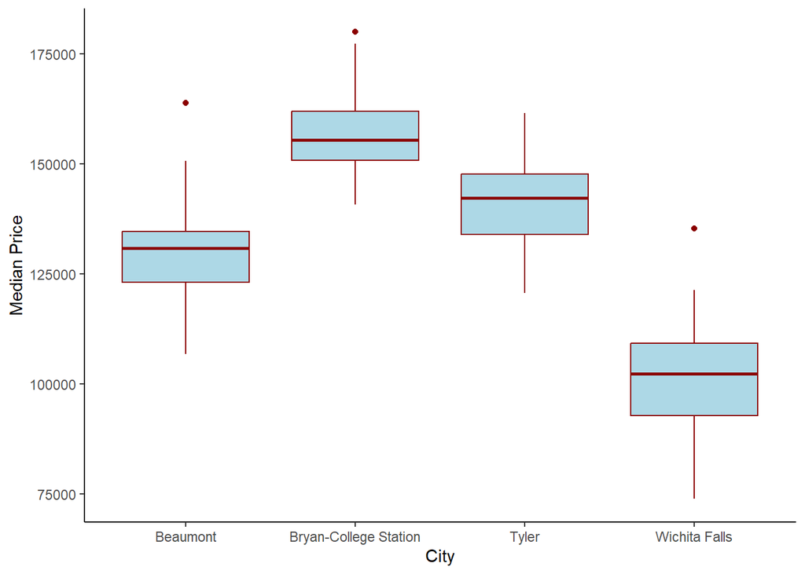

The main insights we can extract from this plot is that the city with the highest median prices is Bryan-College Station while the city that showed the lowest median prices is Wichita Falls. The IQR range among the different cities is similar, only Wichita Falls seems to show a slightly higher inter-quartile range. Let’s see the same plot for the total monthly value of sales by city and year:

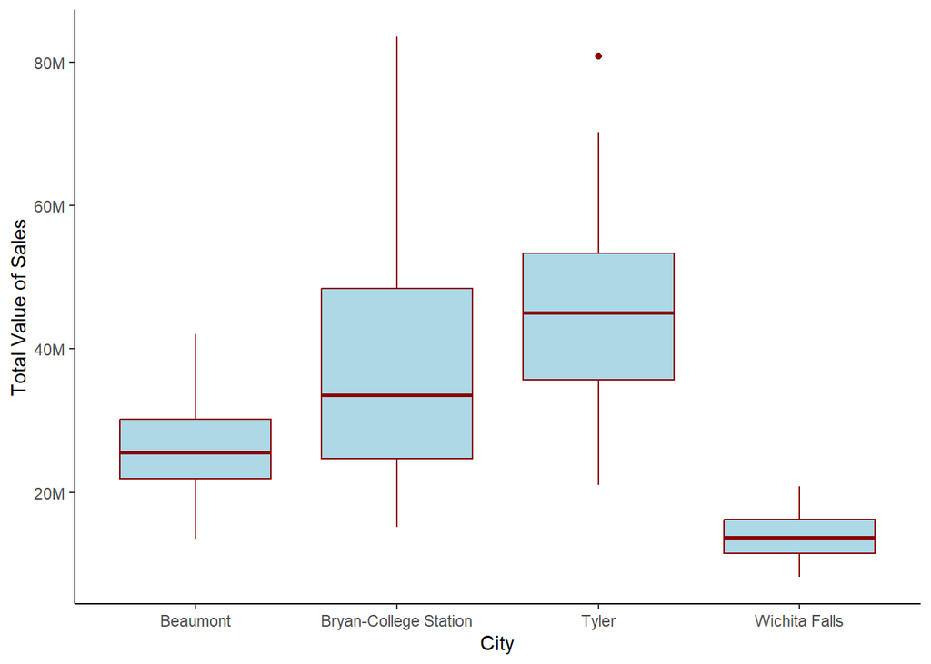

As we can see the total value of monthly sales shows more variability for *Bryan-College Station* and *Tyler* while *Whichita Falls* shows very little volatility for this variable. Now, an interesting one, let’s look at the boxplots by year:

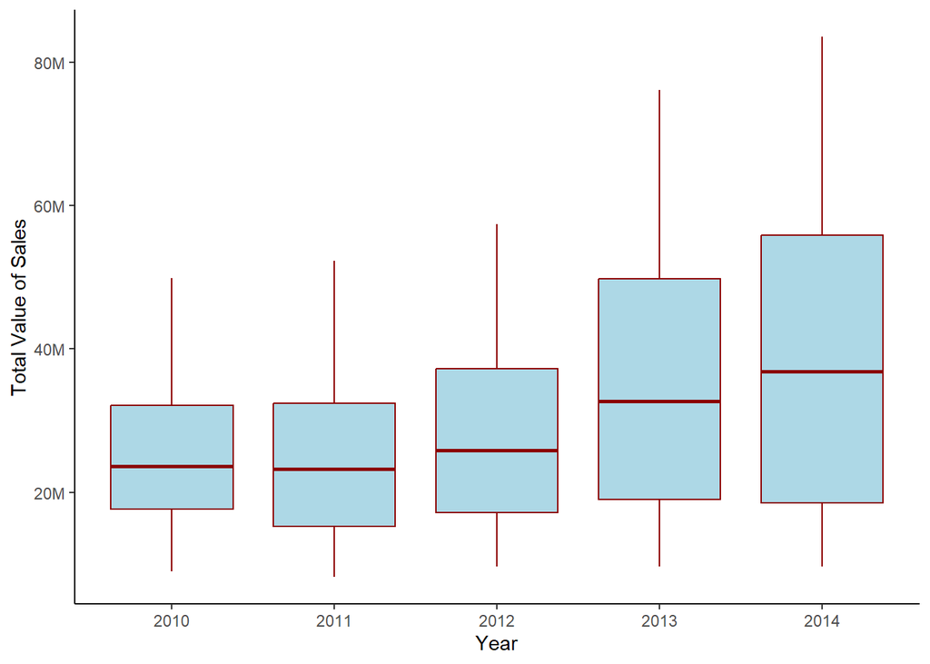

As I imagined this plot shows how the total value of sales in M$ increased with time. This is a characteristic of time series, that are time-dependent. It also shows that the variability increased over time (the IQR range is much higher in 2014 compared to 2010 or 2011).

Let’s now try to find a way to analyze the sales across different months of the same year, by city:

[interactive chart not shown]

Finally here is a line chart to compare sales between cities and years:

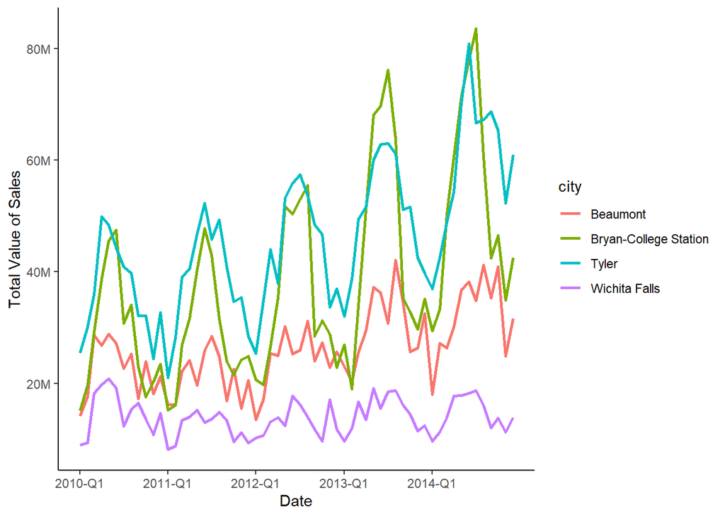

The main insights of this last plot are the following:  
- Tyler & Bryan-College Station show high seasonality in their real estate market (i.e. higher volume in summer lower volume in winter)  
- Tyler & Bryan-College Station also show an increasing trend over time, while Beaumont and especially Wichita Falls seem to follow a flat trend.